# Name, Registration number

# Exercises: exploring the SIR model

Now we can make some modifications to the model parameters, and observe how the model output changes.

## Exercise 1

Find the number of individuals which will be infectious on days: 5, 10 and 25.4

*Hint: combine the code from steps 2–3 in part A, and edit the times you want to compute the solution at in step 2…*

```r
time <- seq(from = 0, to = 30, by = 0.1)
out <- lsoda(func = SIR.model, y = init, parms = pars, times = time)
out <- as.data.frame(out)
for (i in c(50,100,254)+1) {
  print(round(out[i,]$I))
}
```

```
[1] 463
[1] 284
[1] 6
```

## Exercise 2

Three interventions have been proposed which will lower the transmission rate. The expected transmission rates under each intervention are expected to be: 1.25, 0.75 and 0.1. For each of these interventions, find and plot the solution over 30 days.

*Hint: for each new transmission rate, you can re-use your code in steps 2–4 of the walkthrough. You will need to change the model parameters you specify in step 2.*

**Advanced:** if you are familiar with R programming, you are welcome to test yourself by completing this problem using using a for loop.

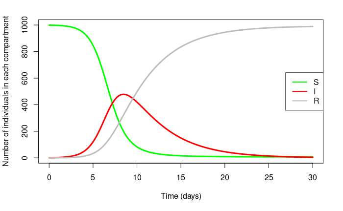

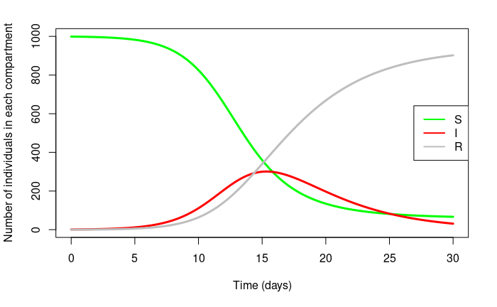

```r
for (i in c(1.25,0.75,0.1)) {
  pars <- list(beta = i, gamma = 1/4)
  out <- lsoda(func = SIR.model, y = init, parms = pars, times = time)
  out <- as.data.frame(out)
  plot(out$time, out$S,
     type = 'l', col = 'green', ylab = "Number of individuals in each compartment",
     xlab = "Time (days)", lwd = 3, ylim = c(0, 1000))

# Next, we can add lines for time against infecteds, and time against recovered/removed.
lines(out$time, out$I, col = 'red', lwd = 3)
lines(out$time, out$R, col = 'grey', lwd = 3)

# Finally, we can add a legend so we know what lines correspond to what compartment.
legend("right", legend = c("S","I","R"), col = c("green","red","grey"), lwd = 2)
}
```

[figure not shown]

```r
NA
```

## Exercise 3

Under each intervention, approximately how many people are infected in the first 30 days?

*Hint: look at the number of susceptibles on the final day (day 30). Everyone on the final day who is not susceptible must have been infected at some point during the course of the epidemic. Recall there were 1000 individuals in the population at the start of the epidemic.*

```r
for (i in c(1.25,0.75,0.1)) {
  pars <- list(beta = i, gamma = 1/4)
  out <- lsoda(func = SIR.model, y = init, parms = pars, times = time)
  out <- as.data.frame(out)
  print(999-round(out[out$time==30,]$S))
}
```

```
[1] 992
[1] 932
[1] 1
```

## Exercise 4

1. Calculate the expected R0 value of the disease under each intervention.

2. How can these R0 values explain the behaviour in your model output?